# Part II - An Explanatory Analysis of Loan Data from Prosper.

## by Neto Anyama

## Investigation Overview

This is part two of my data visualization project. I visualized data from Prosper loans, recorded between 2005 and 2014. I obtained this dataset from [here](https://www.google.com/url?q=https://s3.amazonaws.com/udacity-hosted-downloads/ud651/prosperLoanData.csv&sa=D&ust=1554484977406000). The dataset contained 113,937 entries, with 81 columns. There are no duplicate values.

My main aim in this project was to determine what factors (such as loan term, occupation, income range, amount borrowed, among others) affected the annual percentage rate accorded to each borrower. My secondary aim was to observe the annual trends in features such as APR, Loan Amount, Monthly Income etc.

## Dataset Overview

The dataset contained 113,937 entries, with 81 columns. There are no duplicate values. Some of the relevant columns are as follows:

- BorrowerAPR
- Loan Year
- Original Loan Amount
- Average Credit Score
- Income Range
- Listing Category
- Stated Monthly Income
- Occupation

## Distribution of Annual Percentage Rates

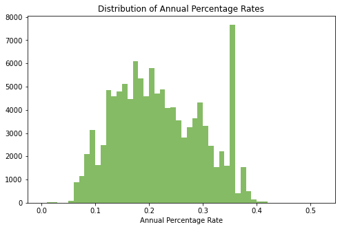

## Yearly Trend in Patronising Prosper

In spite of an intial slow start, with a rise and fall in patronage, Prosper saw a steady rise in patronage from 2009 that peaked in 2013. Unfortunately, there was a sharp drop between 2013 and 2014.

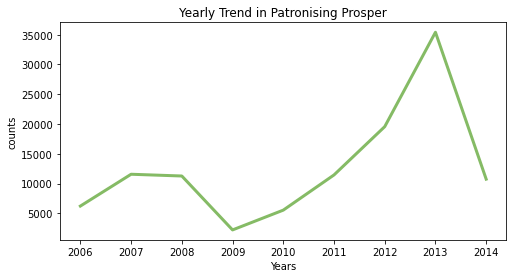

## Top 5 Reasons for Taking Loans

Debt Consolidation (58,308 borrowers/51.19%) is by far the most common reason why the borrowers in this dataset sought loans.

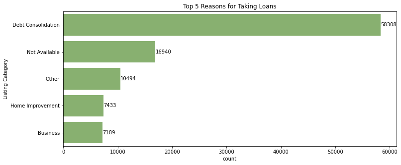

## Income Range vs Annual Percentage Rate

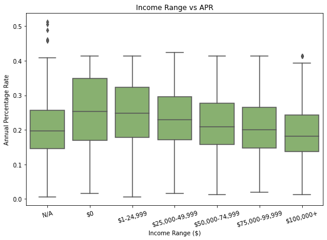

## Yearly Trend in Average APR

There was a steady increase in Annual Percentage Rate between the years 2007 and 2011. However, after 2011, there was a steep decline in APR, reducing with each year. This drop in APR may be regarded as positive by borrowers.

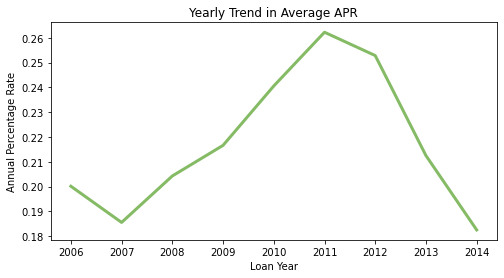

## Relationship between a Borrower's Average Credit Score and APR

A borrower's average credit score has a negative correlation with APR received. Therefore, a higher credit score tends to earn a lower annual percentage (interest) rate.

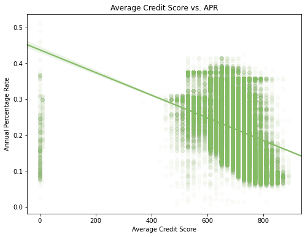

## Yearly Trend in Original Loan Amount against Monthly Income

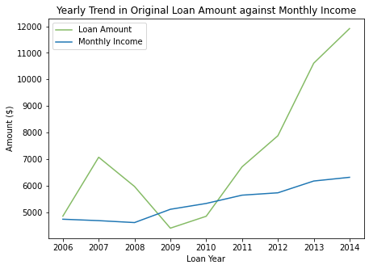